# Independent Project: Ancient DNA

Caroline S.

2023-05-09

# Introduction

Recent advancements in DNA sequencing technologies have enabled the analysis of ancient DNA from a wide range of archaeological samples, from human remains to environmental materials.

The study of ancient DNA has revolutionized our understanding of human evolution, migration patterns, and population dynamics, and has shed light on the interactions between humans and their environment throughout history.

In this project, I explore the use of R for analyzing ancient DNA data, including quality control, data filtering, and statistical analyses.

My aim is to provide a comprehensive guide for researchers interested in using R for analyzing ancient DNA data, and to showcase the potential of R for advancing our understanding of human history and evolution.

# Libraries

```r
#if (!requireNamespace("BiocManager", quietly=TRUE))
#    install.packages("BiocManager")

#install.packages("devtools")
#devtools::install_github("bodkan/admixr")
#BiocManager::install("bedtools")
#BiocManager::install("gdsfmt")
#BiocManager::install("SNPRelate")
#install.packages("adegenet")
#install.packages("mapdata")
#install.packages("qqman")
library(admixr)
library(tidyverse)
library(here)
library("devtools")
library(gdsfmt)
library(SNPRelate)
library(adegenet)
library(ggplot2)
library(dplyr)
library(ggmap)
library(maps)
library(mapdata)
library(data.table)
library(rrBLUP)
library(qqman)
```

# Data

## Background Info on Data

The field of aDNA has revolutionized our understanding of the past by providing insights into the genetic history of extinct and present-day populations. The availability of large-scale datasets, such as the Allen Ancient DNA Resource (AADR) dataset, has facilitated the analysis of genetic variation in thousands of individuals from different time periods and geographic locations.

There are two AADR datasets: **“1240K”** : Ancient and present-day individuals (from either shotgun sequencing data or in-solution target capture, with a range of coverages) at 1,233,013 sites,

**“1240K+HO”**: Data from the above set merged with present-day individuals typed on the Human Origins array with 597,573 sites.

(We will be using **“1240K+HO”**)

All data released here: (a) have already been published (some by our group and some by other groups - see full list of references below), (b) have permissions appropriate for fully public data release, (c) have data reported for a set of 1,233,013 sites in the genome (or 597,573 sites for present-day individuals genotyped on the Affymetrix Human Origins array). For most individuals, genetic data are represented by randomly sampled sequences at positions covered by at least one sequence.

both dataset comes in multiple files organized:

*.anno*: Rich meta-information for each individual. *.ind* : Three columns: Individual ID, sex determination, and group label (population). *.snp* : Information on each analyzed SNP position (SNP id, physical/genetic location and reference/variant alleles, where the reference allele matches hg19). *.geno*: Genotypes

## Reading In The Data

- This section involves reading in data files and downloading annotation information from the AADR dataset (v54.1.p1_HO_public).
- The ‘prefix’ variable is used to specify the directory path where the data files are located.
- The ‘list.files’ function is then used to list all the files with the prefix in the specified directory.
- The ‘read.table’ function is used to read in the SNP and individual information files with explicit file encoding (UTF-8) from the data directory using the ‘here’ package.
- Finally, the ‘anno_url’ variable is used to specify the URL of the annotation file for the dataset. The ‘read.table’ function is again used to read in the annotation information with the appropriate parameters for the file format and fill option.
- The .anno file is read directly from the AADR website: https://reich.hms.harvard.edu/allen-ancient-dna-resource-aadr-downloadable-genotypes-present-day-and-ancient-dna-data *

```r
prefix <- here("data","v54.1.p1_HO_public")
list.files(path = dirname(prefix), pattern = basename(prefix), full.names = TRUE)
```

```
## [1] "/Users/solis/Desktop/GradSchool/second_semester/Computer_Modeling/Independant_Project_Caroline/data/v54.1.p1_HO_public.anno"
## [2] "/Users/solis/Desktop/GradSchool/second_semester/Computer_Modeling/Independant_Project_Caroline/data/v54.1.p1_HO_public.geno"
## [3] "/Users/solis/Desktop/GradSchool/second_semester/Computer_Modeling/Independant_Project_Caroline/data/v54.1.p1_HO_public.ind"
## [4] "/Users/solis/Desktop/GradSchool/second_semester/Computer_Modeling/Independant_Project_Caroline/data/v54.1.p1_HO_public.snp"
```

```r
# Read in the SNP information with explicit file encoding
snp <- read.table(here::here("data","v54.1.p1_HO_public.snp"), header = FALSE, fileEncoding = "UTF-8")

# Read in the individual information with explicit file encoding
ind <- read.table(here::here("data","v54.1.p1_HO_public.ind"), header = FALSE, fileEncoding = "UTF-8")

# Read in the annotation information
anno_url <- "https://reichdata.hms.harvard.edu/pub/datasets/amh_repo/curated_releases/V54/V54.1.p1/SHARE/public.dir/v54.1.p1_HO_public.anno"
anno <- read.table(anno_url, header = TRUE, sep = "\t", fill = TRUE)
```

# Data Wrangling

## Filtering Out Transversions Only

Link to softwares: https://reich.hms.harvard.edu/software

Eigenstrat is a software package used for population genetic analysis. It was designed to perform principal component analysis (PCA) on large genotype datasets in order to infer population structure and identify genetic differences among populations.

```r
snps <- eigenstrat(prefix) #read in the genotype data stored in the EIGENSTRAT format files (.geno, .snp, .ind)

# read in the EIGENSTRAT object containing the remaining SNPs
new_snps <- transversions_only(snps)
```

## Performing PCA

PCA: Principal Component Analysis.

- It is a statistical technique used to analyze and reduce high-dimensional datasets by transforming the data into a lower-dimensional space, while still retaining as much of the original variation as possible.
- PCA can be used to identify patterns and relationships in the data and to explore the structure of complex datasets.
- In genetics, PCA is often used to visualize genetic relationships between individuals and populations, and to identify genetic differences and similarities among different groups.

```r
# Read in the SNP data
snps <- read.table(new_snps$snp)

# Convert the SNP data to a matrix
snps_mat <- data.matrix(snps)

# Perform PCA on the SNP data
pca_results <- prcomp(snps_mat)

# View the PCA results
summary(pca_results)
```

```
## Importance of components:
##                             PC1       PC2   PC3   PC4    PC5    PC6
## Standard deviation     56907369 1.725e+05 5.398 1.317 0.8746 0.1002
## Proportion of Variance        1 1.000e-05 0.000 0.000 0.0000 0.0000
## Cumulative Proportion         1 1.000e+00 1.000 1.000 1.0000 1.0000
```

## Subsetting South American Samples

In this section, a list of South American countries is created and stored as south_american_countries.

  ```r
  # Create a list of South American countries
  south_american_countries <- c("Argentina", "Bolivia", "Brazil", "Chile", "Colombia", "Ecuador", "Guyana", "Paraguay", "Peru", "Suriname", "Uruguay", "Venezuela")

  # Filter the data for South American samples
  south_america_data <- anno %>%
    filter(Political.Entity %in% south_american_countries) #the given column name for countries: Political.Entity

  head(south_america_data)
  ```

  ```
  ##     Genetic.ID Master.ID Skeletal.code Skeletal.element
  ## 1 HGDP00702.HO HGDP00702            ..               ..
  ## 2 HGDP00703.HO HGDP00703            ..               ..
  ## 3 HGDP00704.HO HGDP00704            ..               ..
  ## 4 HGDP00706.HO HGDP00706            ..               ..
  ## 5 HGDP00832.HO HGDP00832            ..               ..
  ## 6 HGDP00837.HO HGDP00837            ..               ..
  ##   Year.data.from.this.individual.was.first.published..for.a.present.day.individuals.we.give.the.data.of.the.data.reported.here..missing.GreenScience.2010..Vi33.15..Vi33.26...Olalde2018..I2657...RasmussenNature2010..Australian..
  ## 1                                                                                                                                                                                                                              2012
  ## 2                                                                                                                                                                                                                              2012
  ## 3                                                                                                                                                                                                                              2012
  ## 4                                                                                                                                                                                                                              2012
  ## 5                                                                                                                                                                                                                              2012
  ## 6                                                                                                                                                                                                                              2012
  ##             Publication
  ```

  [output cut: 139 more lines]

## Merging .ind file and .anno “South America” subset

This section of code is preparing the metadata for the samples that were used in the analysis.

- First, the column names in the .ind file are renamed to match the column names in the summary table.
- Then, select() function is used to keep only the desired columns from the .ind file and the south_america_data data frames.
- Next, the two data frames are merged based on the Genetic.ID and Group.ID columns.
- The resulting merged_df data frame is then subsetted to keep only the columns for Genetic.ID, Group.ID, Sex, Political.Entity, Lat., and Long., and the column names are renamed as needed.
- The resulting data frame contains the metadata for the samples used in the analysis, including their geographic location (latitude and longitude) and the country they belong to. head() function is then used to display the first few rows of the resulting data frame.

```r
# rename the columns in the .ind file to match the summary table
colnames(ind) <- c("Genetic.ID", "Sex", "Group.ID")

# select the columns to keep from the ind data frame
ind_subset <- ind %>%
  select(Genetic.ID, Group.ID, Sex)

# select the columns to keep from the south_america_data data frame
south_america_subset <- south_america_data %>%
  select(Genetic.ID, Group.ID, Political.Entity, Lat., Long.)

# merge the two data frames
merged_df <- merge(ind, south_america_data, by = c("Genetic.ID", "Group.ID"))

# select only the desired columns
merged_df <- merged_df[, c("Genetic.ID", "Group.ID", "Sex", "Political.Entity", "Lat.", "Long." )]

# rename the columns as needed
colnames(merged_df) <- c("Genetic.ID", "Group.ID", "Sex", "Country","Lat.", "Long.")

head(merged_df)
```

```
##           Genetic.ID                                     Group.ID Sex   Country
## 1   A_Karitiana-4.DG               Ignore_Karitiana(discovery).DG   M    Brazil
## 2 Aconcagua_noUDG.SG            Argentina_Aconcagua_Inca_500BP.SG   M Argentina
## 3   B_Karitiana-3.DG                                 Karitiana.DG   M    Brazil
## 4            BI16.SG                                 Karitiana.SG   M    Brazil
## 5            CH13.SG Uruguay_Rocha_PreColonial.SG_1d.rel.CH19B.SG   U   Uruguay
## 6           CH19B.SG                 Uruguay_Rocha_PreColonial.SG   F   Uruguay
##      Lat.  Long.
## 1     -10    -63
## 2  -32.65 -70.01
## 3     -10    -63
## 4     -10    -63
## 5 -34.486 -54.34
## 6 -34.486 -54.34
```

## Grouping Samples By Country

This section is summarizing the populations for each country based on the merged data frame created in the previous section.

- The group_by() function is used to group the merged data frame by country, and then the summarize() function is used to create a new data frame that summarizes each country’s population.
- The paste() function is used to concatenate the different Group IDs within each country, separated by commas, and the resulting string is stored in the populations column of the country_summary data frame.
- Finally, the print() function is used to display the country_summary data frame on the console.

```r
# summarize populations for each country
country_summary <- merged_df %>%
  group_by(Country) %>%
  summarize(populations = paste(Group.ID, collapse = ", "))
print(country_summary)
```

```
## # A tibble: 5 × 2
##   Country   populations
##   <chr>     <chr>
## 1 Argentina Argentina_Aconcagua_Inca_500BP.SG, Argentina_ArroyoSeco2_7700BP, Ar…
## 2 Brazil    Ignore_Karitiana(discovery).DG, Karitiana.DG, Karitiana.SG, Surui.D…
## 3 Colombia  CLM.DG, CLM.DG, CLM.DG, CLM.DG, CLM.DG, CLM.DG, CLM.DG, CLM.DG, CLM…
## 4 Peru      Peru_Cuncaicha_9000BP, Peru_Cuncaicha_4200BP, Peru_Cuncaicha_3300BP…
## 5 Uruguay   Uruguay_Rocha_PreColonial.SG_1d.rel.CH19B.SG, Uruguay_Rocha_PreColo…
```

# Plotting

## Plot Country Summary

This section summarizes the populations for each country included in the merged dataset.

- The merged_df data frame is first grouped by country using the group_by() function from the dplyr package, and then the summarize() function is used to count the number of populations in each country with the n() function.
- The resulting country_summary data frame contains two columns: Country and populations.

Then, a bar plot of the population sizes by country is created using the ggplot2 package.

- The country_summary data frame is used as the data source, and the aes() function is used to map Country to the x-axis and populations to the y-axis.
- geom_bar() is used to create the bar plot, and the stat = “identity” argument is included to indicate that the height of each bar should be determined by the actual values in populations.
- Finally, labs() is used to set the title and axis labels for the plot.

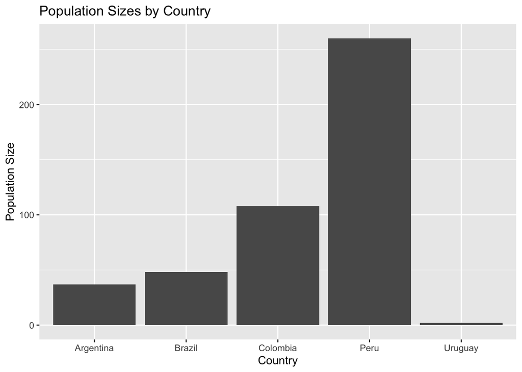

```r
# summarize populations for each country
country_summary <- merged_df %>%
  group_by(Country) %>%
  summarize(populations = n())

# create bar plot of country populations
country_plot <- ggplot(country_summary, aes(x = Country, y = populations)) +
  geom_bar(stat = "identity") +
  labs(title = "Population Sizes by Country", x = "Country", y = "Population Size")
print(country_plot)
```

```r
ggsave(file = here("output", "country_plot.png"), plot = country_plot)
```

## Creating Scatterplot

In this section, the latitude and longitude columns of the merged_df data frame are converted from characters to numerics because they were originally read in as character data types.

- Any rows in the merged_df data frame that contain NA values in the Lat. or Long. columns are removed using the complete.cases() function.
- Finally, a scatter plot is created using the ggplot2 package to visualize the geographic distribution of the samples. Each data point represents a sample, with the color indicating the country of origin.

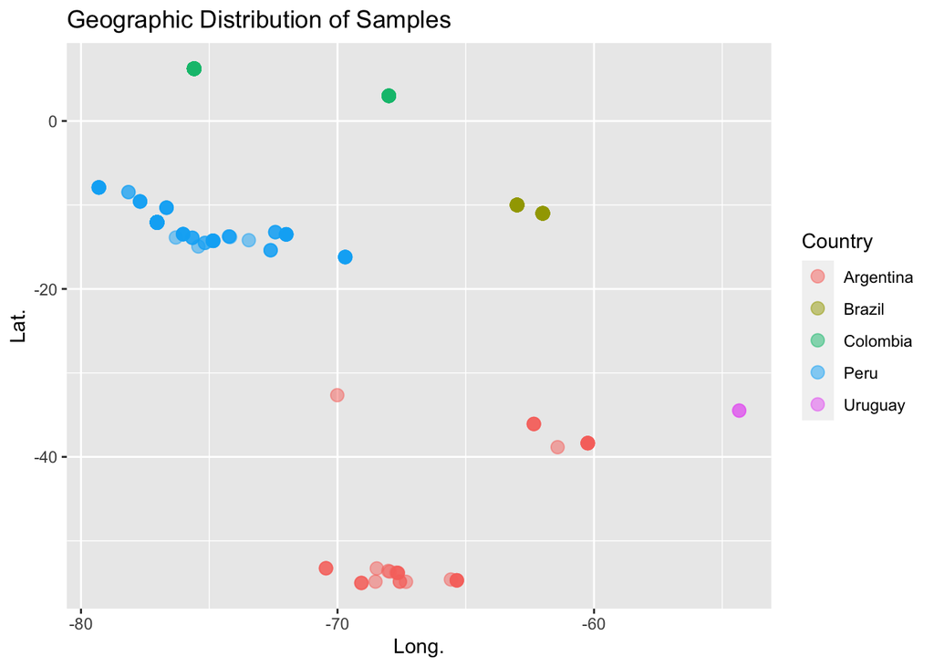

```r
#changing coordinates to numeric because character wasn't continuous
merged_df$Lat. <- as.numeric(merged_df$Lat.)
merged_df$Long. <- as.numeric(merged_df$Long.)
merged_df <- merged_df[complete.cases(merged_df[c("Lat.", "Long.")]), ] #remove rows that have NAs in coordinate columns

# Create scatter plot of data points
samples_plot <- ggplot(merged_df, aes(x = Long., y = Lat., color = Country)) +
  geom_point(alpha = 0.5, size = 3) +
  labs(title = "Geographic Distribution of Samples")

print(samples_plot)
```

```r
ggsave(file = here("output", "samples_plot.png"), plot = samples_plot)
```

## Add South America Map

In this section, a plot is created to display the geographic distribution of the samples included in the dataset.

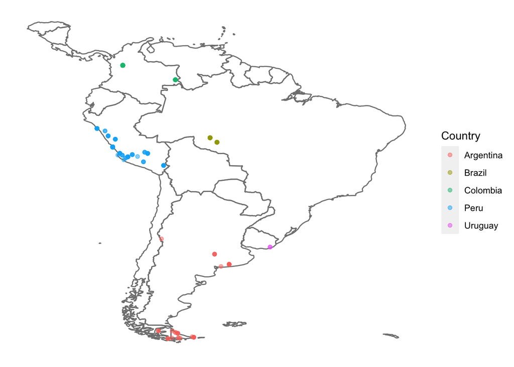

```r
# Next, use the ggplot() function to create a new plot object
map_plot <- ggplot()+
  borders("world", xlim=c(-85, -30), ylim=c(-60, 15)) +
  theme(panel.background = element_blank()) + # Use the borders() function to add a map of South America to the plot
  geom_point(data = merged_df, aes(x = Long., y = Lat., color = Country),alpha = 0.5) + # Use the geom_point() function to add markers for the coordinates in the data frame
  scale_color_discrete(name = "Country") + # Use the scale_color_discrete() function to set the color scale to a discrete scale
  theme(panel.background = element_blank(), # Use the theme() function to customize the appearance of the map

               axis.title = element_blank(),
               axis.text = element_blank(),
               axis.ticks = element_blank())

print(map_plot)
```

```r
ggsave(file = here("output", "map_plot.png"), plot = map_plot)
```

## Manhattan Plot

*What is a Manhattan Plot?* A Manhattan plot is a graphical representation of the results of a genome-wide association study (GWAS).

In a GWAS, genetic markers called single nucleotide polymorphisms (SNPs) are analyzed for association with a particular trait or disease.

A Manhattan plot displays the -log10-transformed p-values of the SNPs on the y-axis, and their physical positions on the x-axis (usually by chromosome).

In the plot, each point represents a SNP, and the height of the point represents its significance, with higher points indicating more significant associations.

The plot is called a “Manhattan plot” because the shape of the plot can resemble the skyline of Manhattan.

Manhattan plots are useful for visualizing genome-wide association results because they allow researchers to quickly identify genomic regions that contain SNPs that are associated with the trait or disease of interest.

These regions may contain candidate genes or regulatory elements that could be further investigated for their role in the trait or disease.

```r
#change names of columns in snp data frame
colnames(snps) <- c("SNP_ID", "Chromosome", "Genetic_Distance", "Position", "Ref_Allele", "Alt_Allele")

# Convert Ref_Allele and Alt_Allele to numeric values
snps$Ref_Num <- ifelse(snps$Ref_Allele == "A", 1, ifelse(snps$Ref_Allele == "C", 2, ifelse(snps$Ref_Allele == "G", 3, ifelse(snps$Ref_Allele == "T", 4, NA))))
snps$Alt_Num <- ifelse(snps$Alt_Allele == "A", 1, ifelse(snps$Alt_Allele == "C", 2, ifelse(snps$Alt_Allele == "G", 3, ifelse(snps$Alt_Allele == "T", 4, NA))))

# Add a column for p-values
snps <- cbind(snps, p_value = rep(NA, 597573))

# Calculate the p-values for each SNP
snps[, "p_value"] <- apply(snps[, c("Ref_Num", "Alt_Num")], 1, function(x) {
  het <- min(x)
  hom_alt <- max(x)
  hom_ref <- 1 - het - hom_alt
  chisq <- ((het - 0.5)^2)/0.5 + ((hom_alt - 1)^2)/1 + ((hom_ref - 0)^2)/1
  1 - pchisq(chisq, 1)
})

#select the needed columns for plot
snps <- snps[, c("SNP_ID", "Chromosome", "Position", "p_value")]

# Chrom column is originally integer must be numeric
snps$Chromosome <- as.numeric(snps$Chromosome)

# Print the modified data frame
head(snps)
```

```
##       SNP_ID Chromosome Position      p_value
## 1  rs3094315          1   752566 2.385635e-04
## 2  rs7419119          1   842013 3.375078e-14
## 3 rs13302957          1   891021 2.385635e-04
## 4  rs6696609          1   903426 5.475368e-10
## 5     rs8997          1   949654 2.385635e-04
## 6  rs9442372          1  1018704 2.385635e-04
```

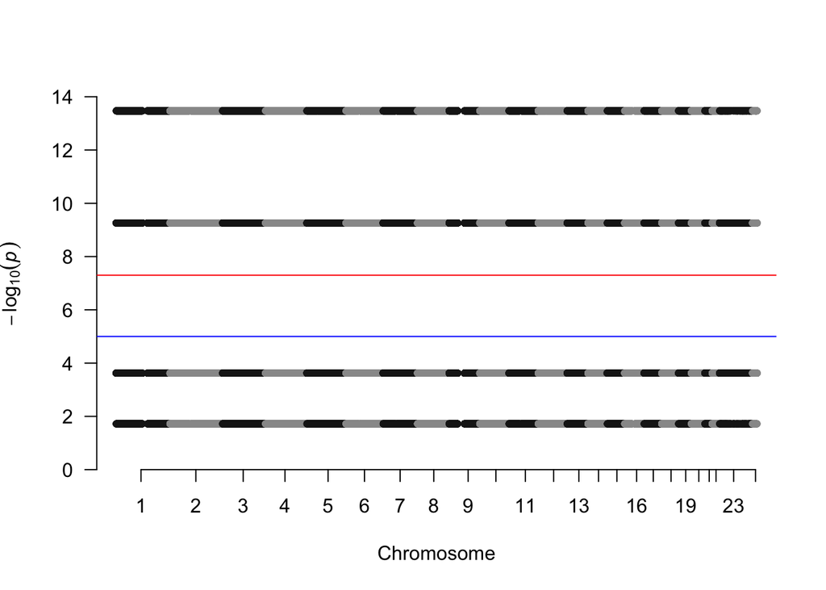

```r
# Make the Manhattan plot
manhattan(x = snps, chr = "Chromosome", snp = "SNP_ID",bp = "Position", p = "p_value" )
```

What it should look like 👀  
|  
|  
|  
|  
V

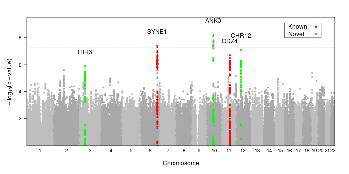